# Social media analysis

2023-04-23

```r
library(readr)
library(readr)
library(MVA)
library(pROC)
```

```r
library(HSAUR2)
library(SciViews)
library(scatterplot3d)
library(car)
library(lattice)
library(GGally)
library(caTools)
library(ggplot2)
library(ggridges)
library(ggvis)
library(ggcorrplot)
library(ggthemes)
library(cowplot)
library(gapminder)
library(gganimate)
library(dplyr)
library(tidyverse)
library(grid)
library(gridExtra)
library(RColorBrewer)
library(Hotelling)
library(stats)
library(biotools)
library(factoextra)
library(FactoMineR)
library(ggfortify)
library(psych)
library(cluster)
library(corrplot)
library(caret)
smedia = read_csv('~/Documents/Courses/Multivariate Analysis/Class project /Class_Survey.csv')
View(smedia)

colSums(is.na(smedia)) #Replacing missing data with mean of the column
```

```
##                                   Student
##                                         0
##                                      Week
##                                         0
##                            Whatsapp (hrs)
##                                         0
##                           Instagram (hrs)
##                                         0
##                             Snapchat(hrs)
##                                         0
##                            Telegram (hrs)
##                                         1
##                  Facebook/Messenger (hrs)
##                                         0
##                              BeReal (hrs)
##                                         0
##                              TikTok (hrs)
##                                         0
##                              WeChat (hrs)
##                                         0
##                             Twitter (hrs)
##                                         0
##                            Linkedin (hrs)
##                                         0
##                            Messages (hrs)
##                                         0
##      Total Social Media Screen Time (hrs)
##                                         0
## Number of times opened (hourly intervals)
##                                         1
##                    Social Media Addiction
##                                         0
```

```r
smedia %>%
  mutate_if(is.numeric, ~replace_na(.,mean(., na.rm = TRUE)))
```

```
## # A tibble: 175 × 16
##    Student Week  Whats…¹ Insta…² Snapc…³ Teleg…⁴ Faceb…⁵ BeRea…⁶ TikTo…⁷ WeCha…⁸
##    <chr>   <chr>   <dbl>   <dbl>   <dbl>   <dbl>   <dbl>   <dbl>   <dbl>   <dbl>
##  1 AJAY A… Feb …    8.9     7.1     1.9     0.02       0    0          0       0
##  2 AJAY A… Mar …   11.8    11.2     2.45    0.06       0    0          0       0
##  3 AJAY A… Mar …   12.2    16.8     3.25    0.01       0    0          0       0
##  4 AJAY A… Mar …   12.3    12.9     3.12    0.06       0    0          0       0
##  5 AJAY A… Mar …    8.5    11.9     1.9     0.05       0    0          0       0
##  6 AJAY A… Apr …    9.5    11.2     1.2     0.16       0    0          0       0
##  7 AJAY A… Apr …    8.25   11.8     1.67    0          0    0          0       0
##  8 TEJESH… Feb …    5.7    12       2       0.25       0    0.35       0       0
##  9 TEJESH… Mar …    4.5     7.25    1.4     0.35       0    0.21       0       0
## 10 TEJESH… Mar …    6.8     4.5     2.1     0.33       0    0.65       0       0
## # … with 165 more rows, 6 more variables: `Twitter (hrs)` <dbl>,
## #   `Linkedin (hrs)` <dbl>, `Messages (hrs)` <dbl>,
## #   `Total Social Media Screen Time (hrs)` <dbl>,
## #   `Number of times opened (hourly intervals)` <dbl>,
## #   `Social Media Addiction` <chr>, and abbreviated variable names
## #   ¹`Whatsapp (hrs)`, ²`Instagram (hrs)`, ³`Snapchat(hrs)`, ⁴`Telegram (hrs)`,
## #   ⁵`Facebook/Messenger (hrs)`, ⁶`BeReal (hrs)`, ⁷`TikTok (hrs)`, …
```

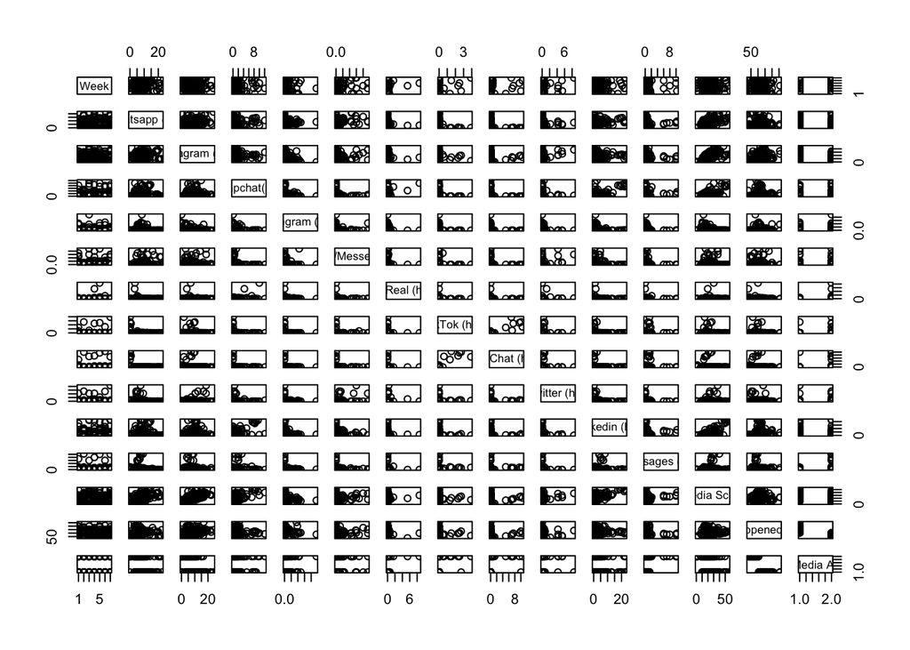

```r
plot(smedia[-1]) #There is no linear relationship between the variables
```

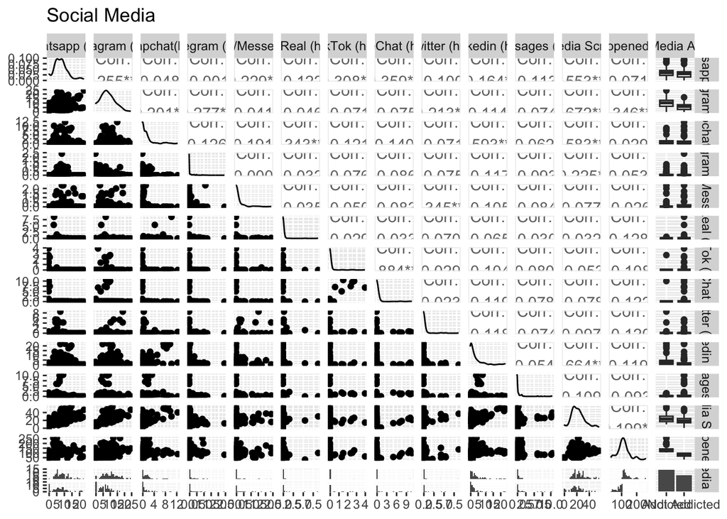

```r
ggpairs(data=smedia[-1:-2], title="Social Media")
```

> There is a positive correlation between -
1. Linkedin and Social Media screen time
2. WeChat and TikTok
3. Twitter and Facebook/ Messenger
4. LinkedIn and Snapchat
5. Snapchat and Social media screen time
6. BeReal and Snapchat
7. Instagram and number of times opened
8. Social Media screen time and Instagram
9. Instagram and WhatsApp
10. Social Media screen time and WhatsApp

> There is a negative correlation between -
1. Telegram and Instagram
2. TikTok and WhatsApp
3. WeChat and WhatsApp

> Addiction is considered when number of times we have opened our apps are greater than 105.

> We can see that Instagram is correlated with number of times screen opened, which means it has a significant contribution towards users having social media addiction.

> Why is that? What factors are making users open Instagram frequently and not the other social media apps?

```r
# Load the dataset

# Convert the "Social Media Addiction" column to a binary variable
smedia$addiction <- ifelse(smedia$`Social Media Addiction` == "Addicted", 1, 0)
smedia = smedia[, -16]
smedia = smedia[, -15]
# Split the data into training and testing sets
set.seed(123)
split <- sample.split(smedia$addiction, SplitRatio = 0.8)
train <- subset(smedia[, -1:-2], split == TRUE)
test <- subset(smedia[, -1:-2], split == FALSE)

# Fit a logistic regression model on the training data
model <- glm(addiction ~ ., data = train, family = binomial)

# Print the summary of the model
summary(model)
```

```
##
## Call:
## glm(formula = addiction ~ ., family = binomial, data = train)
##
## Deviance Residuals:
##    Min      1Q  Median      3Q     Max
## -2.704  -0.827   0.335   0.789   1.725
##
## Coefficients:
##                                        Estimate Std. Error z value Pr(>|z|)
## (Intercept)                             -0.9937     0.5982  -1.661   0.0967 .
## `Whatsapp (hrs)`                       -53.4684   143.0237  -0.374   0.7085
## `Instagram (hrs)`                      -53.1895   143.0232  -0.372   0.7100
## `Snapchat(hrs)`                        -53.7171   143.0222  -0.376   0.7072
## `Telegram (hrs)`                       -53.1801   143.0363  -0.372   0.7100
## `Facebook/Messenger (hrs)`             -54.2094   143.0217  -0.379   0.7047
## `BeReal (hrs)`                         -53.7304   143.0297  -0.376   0.7072
## `TikTok (hrs)`                         -53.1623   142.9879  -0.372   0.7100
## `WeChat (hrs)`                         -53.7010   143.0377  -0.375   0.7073
## `Twitter (hrs)`                        -53.8277   143.0224  -0.376   0.7067
## `Linkedin (hrs)`                       -53.3341   143.0220  -0.373   0.7092
## `Messages (hrs)`                       -53.8394   143.0240  -0.376   0.7066
## `Total Social Media Screen Time (hrs)`  53.4467   143.0220   0.374   0.7086
## ---
## Signif. codes:  0 '***' 0.001 '**' 0.01 '*' 0.05 '.' 0.1 ' ' 1
##
## (Dispersion parameter for binomial family taken to be 1)
##
##     Null deviance: 191.21  on 139  degrees of freedom
## Residual deviance: 142.63  on 127  degrees of freedom
## AIC: 168.63
##
## Number of Fisher Scoring iterations: 5
```

```r
# Make predictions on the test data
predictions <- predict(model, newdata = test, type = "response")

# Convert the probabilities to binary predictions
predicted_classes <- ifelse(predictions > 0.5, 1, 0)

# Calculate the accuracy of the model on the test data
conf_mat <- table(predicted_classes, test$addiction)
conf_mat
```

```
##
## predicted_classes  0  1
##                 0 10  3
##                 1  5 16
```

```r
accuracy <- sum(diag(conf_mat)) / sum(conf_mat)
accuracy
```

```
## [1] 0.7647059
```

> I performed logisitic regression with X ~ Number of hours on each app and its total.

> Accuracy: 76.47%

> Simple logistic model just on the basis of total number of hours spent on social media

```r
# Fit a logistic regression model on the training data
s_model <- glm(addiction ~ `Total Social Media Screen Time (hrs)`, data = train, family = binomial)

# Print the summary of the model
summary(s_model)
```

```
##
## Call:
## glm(formula = addiction ~ `Total Social Media Screen Time (hrs)`,
##     family = binomial, data = train)
##
## Deviance Residuals:
##     Min       1Q   Median       3Q      Max
## -1.9670  -1.1693   0.7268   1.0842   1.3460
##
## Coefficients:
##                                        Estimate Std. Error z value Pr(>|z|)
## (Intercept)                            -0.92092    0.42920  -2.146  0.03190 *
## `Total Social Media Screen Time (hrs)`  0.05465    0.01823   2.997  0.00272 **
## ---
## Signif. codes:  0 '***' 0.001 '**' 0.01 '*' 0.05 '.' 0.1 ' ' 1
##
## (Dispersion parameter for binomial family taken to be 1)
##
##     Null deviance: 191.21  on 139  degrees of freedom
## Residual deviance: 180.81  on 138  degrees of freedom
## AIC: 184.81
##
## Number of Fisher Scoring iterations: 4
```

```r
# Make predictions on the test data
s_predictions <- predict(s_model, newdata = test, type = "response")

# Convert the probabilities to binary predictions
s_predicted_classes <- ifelse(s_predictions > 0.5, 1, 0)

# Calculate the accuracy of the model on the test data
s_conf_mat <- table(s_predicted_classes, test$addiction)
s_conf_mat
```

```
##
## s_predicted_classes  0  1
##                   0  6  2
##                   1  9 18
```

```r
s_accuracy <- sum(diag(s_conf_mat)) / sum(s_conf_mat)
s_accuracy
```

```
## [1] 0.6857143
```

> Accuracy: 68.57%

> Total Social Media Screen Time (hrs) vs. addiction

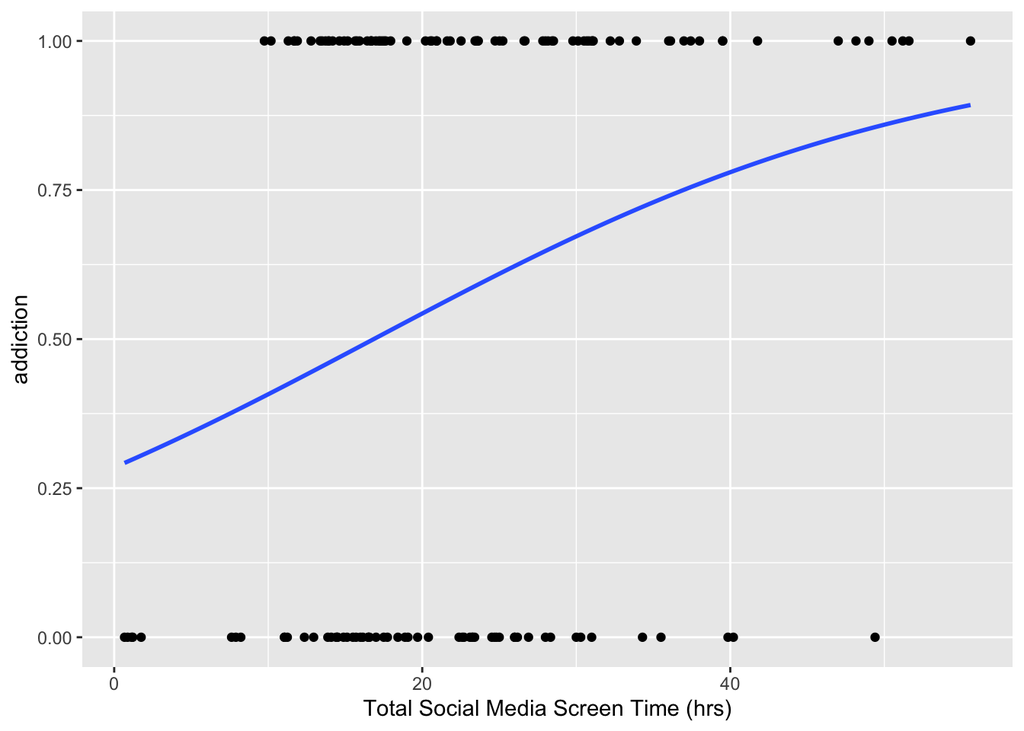

```r
ggplot(train, aes(x = `Total Social Media Screen Time (hrs)`, y = addiction)) +
  geom_point() +
  stat_smooth(method = "glm", method.args = list(family = "binomial"), se = FALSE)
```

> ROC curve of model 1

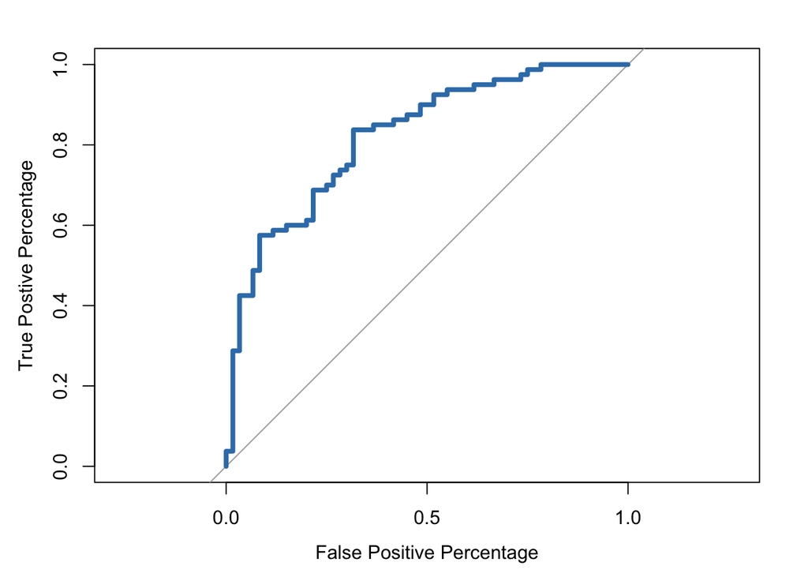

```
##
## Call:
## roc.default(response = train$addiction, predictor = model$fitted.values,     plot = TRUE, legacy.axes = TRUE, xlab = "False Positive Percentage",     ylab = "True Postive Percentage", col = "#377eb8", lwd = 4)
##
## Data: model$fitted.values in 60 controls (train$addiction 0) < 80 cases (train$addiction 1).
## Area under the curve: 0.8213
```

```r
roc(train$addiction,model$fitted.values,plot=TRUE, legacy.axes=TRUE, xlab="False Positive Percentage", ylab="True Postive Percentage", col="#377eb8", lwd=4)
```

> ROC and AUC of both models

```r
roc(train$addiction, model$fitted.values, plot=TRUE, legacy.axes=TRUE, percent=TRUE, xlab="False Positive Percentage", ylab="True Postive Percentage", col="#377eb8", lwd=4, print.auc=TRUE)
```

```
##
## Call:
## roc.default(response = train$addiction, predictor = model$fitted.values,     percent = TRUE, plot = TRUE, legacy.axes = TRUE, xlab = "False Positive Percentage",     ylab = "True Postive Percentage", col = "#377eb8", lwd = 4,     print.auc = TRUE)
##
## Data: model$fitted.values in 60 controls (train$addiction 0) < 80 cases (train$addiction 1).
## Area under the curve: 82.12%
```

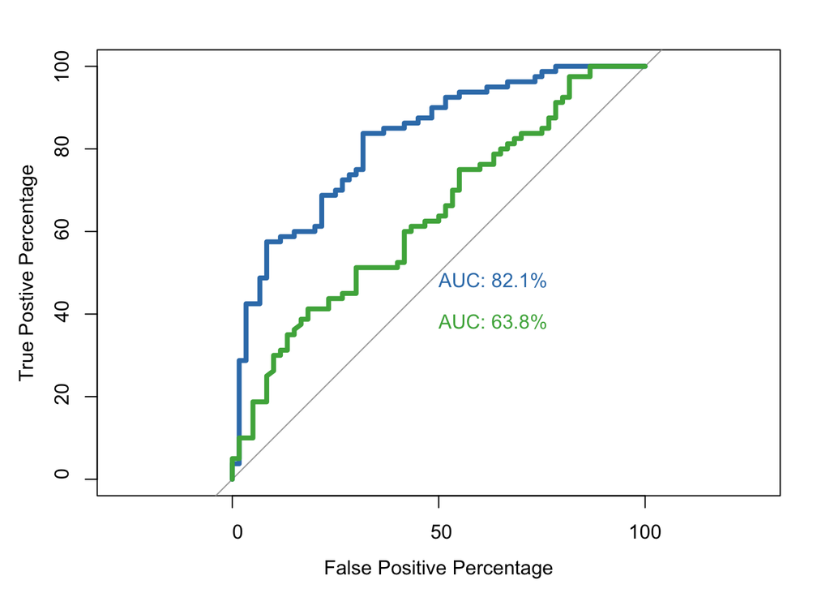

```r
plot.roc(train$addiction, s_model$fitted.values, percent=TRUE, col="#4daf4a", lwd=4, print.auc=TRUE, add=TRUE, print.auc.y=40)
```